# Bitcoin Price Forecasting Using Time Series Models

# Results

## Plot Helper Functions

```r
# ── Unified forecast plot (any scale) ─────────────────────────────────────────
plot_forecast <- function(dates, actual, predicted, title,
                          y_label = "Value", rmse = NULL, mae = NULL) {
  subtitle_txt <- if (!is.null(rmse) && !is.null(mae))
    paste0("Test period  |  RMSE = ", round(rmse, 2), "  |  MAE = ", round(mae, 2))
  else ""

  df <- data.frame(Date = dates, Actual = actual, Predicted = predicted)
  df_long <- reshape2::melt(df, id.vars = "Date",
                            variable.name = "Series", value.name = "Value")

  ggplot(df_long, aes(x = Date, y = Value, colour = Series)) +
    geom_line(linewidth = 0.85, alpha = 0.85) +
    scale_colour_manual(values = c("Actual" = "#2166ac", "Predicted" = "#d6604d")) +
    scale_y_continuous(labels = scales::comma) +
    theme_minimal(base_size = 12) +
    theme(legend.position = "top",
          plot.subtitle    = element_text(size = 10, colour = "grey40"),
          panel.grid.minor = element_blank()) +
    labs(title = title, subtitle = subtitle_txt,
         x = "Date", y = y_label, colour = "")
}

# ── Convert VAR/GARCH return forecasts → USD price ────────────────────────────
# Starting from last_price, chain: P_t = P_{t-1} * exp(r_t / 100)
returns_to_price <- function(returns_pct, last_price) {
  prices <- numeric(length(returns_pct))
  prices[1] <- last_price * exp(returns_pct[1] / 100)
  for (i in seq_along(returns_pct)[-1])
    prices[i] <- prices[i - 1] * exp(returns_pct[i] / 100)
  prices
}
```

## Actual BTC Price Plots — All Models (USD Scale)

All four models are converted to **USD price** for direct visual comparison.

- **VAR / VAR+GARCH:** return forecasts are compounded forward from the last training price using `P_t = P_{t-1} × exp(r_t / 100)`.
- **SARIMA / BSTS:** log-price forecasts are back-transformed with `exp(·)`.

RMSE and MAE in the subtitles are also on the **USD scale**, making them directly comparable across all models for the first time.

```r
# Last known BTC price at end of training window
last_train_price <- as.numeric(tail(daily_data$BTC[index(daily_data$BTC) < test_start], 1))
cat("Last training price (USD):", scales::dollar(last_train_price), "\n")
```

```
## Last training price (USD): $104,638
```

```r
# Actual BTC price during the test window
test_dates_btc <- index(daily_data$BTC[index(daily_data$BTC) >= test_start])
actual_usd     <- as.numeric(daily_data$BTC[index(daily_data$BTC) >= test_start])

# ── VAR multi-step → USD ──────────────────────────────────────────────────────
var_dates      <- index(test_xts)
pred_usd_var   <- returns_to_price(as.numeric(pred_mat[, "rBTC"]), last_train_price)
actual_usd_var <- as.numeric(daily_data$BTC[as.character(var_dates)])

rmse_usd_var <- sqrt(mean((actual_usd_var - pred_usd_var)^2, na.rm = TRUE))
mae_usd_var  <- mean(abs(actual_usd_var  - pred_usd_var),    na.rm = TRUE)

# ── VAR+GARCH rolling → USD ───────────────────────────────────────────────────
pred_usd_vg   <- returns_to_price(pred_mean_rBTC, last_train_price)
actual_usd_vg <- actual_usd_var   # same test dates

rmse_usd_vg <- sqrt(mean((actual_usd_vg - pred_usd_vg)^2, na.rm = TRUE))
mae_usd_vg  <- mean(abs(actual_usd_vg  - pred_usd_vg),    na.rm = TRUE)

# ── SARIMA → USD (exp of log-price forecast) ──────────────────────────────────
sarima_dates   <- as.Date(index(btc_test))
pred_usd_sar   <- exp(as.numeric(fc_sarima$mean))
actual_usd_sar <- exp(as.numeric(btc_test))

rmse_usd_sar <- sqrt(mean((actual_usd_sar - pred_usd_sar)^2, na.rm = TRUE))
mae_usd_sar  <- mean(abs(actual_usd_sar  - pred_usd_sar),    na.rm = TRUE)

# ── BSTS → USD (exp of log-price forecast) ───────────────────────────────────
bsts_dates    <- index(X[index(X) >= test_start])
pred_usd_bsts <- exp(pred_log_bsts)
actual_usd_bsts <- exp(y_test_b)

rmse_usd_bsts <- sqrt(mean((actual_usd_bsts - pred_usd_bsts)^2, na.rm = TRUE))
mae_usd_bsts  <- mean(abs(actual_usd_bsts  - pred_usd_bsts),    na.rm = TRUE)
```

### Model 3: VAR — Multi-Step Ahead (USD)

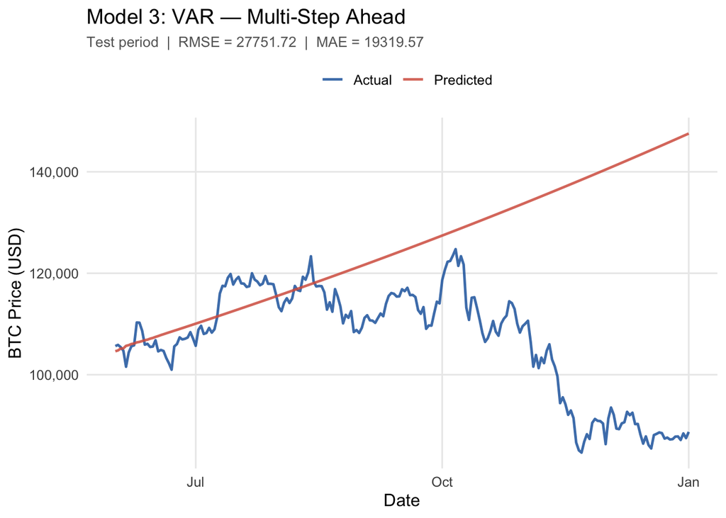

```r
plot_forecast(
  dates     = var_dates,
  actual    = actual_usd_var,
  predicted = pred_usd_var,
  title     = "Model 3: VAR — Multi-Step Ahead",
  y_label   = "BTC Price (USD)",
  rmse      = rmse_usd_var,
  mae       = mae_usd_var
)
```

### Model 4: VAR+GARCH — Rolling 1-Step Ahead (USD)

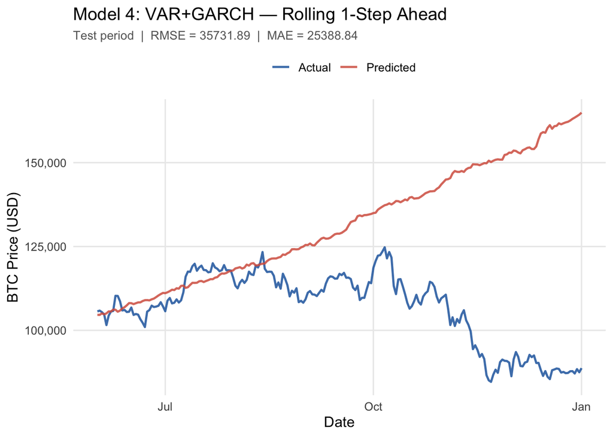

```r
plot_forecast(
  dates     = var_dates,
  actual    = actual_usd_vg,
  predicted = pred_usd_vg,
  title     = "Model 4: VAR+GARCH — Rolling 1-Step Ahead",
  y_label   = "BTC Price (USD)",
  rmse      = rmse_usd_vg,
  mae       = mae_usd_vg
)
```

### Model 5: SARIMA (USD)

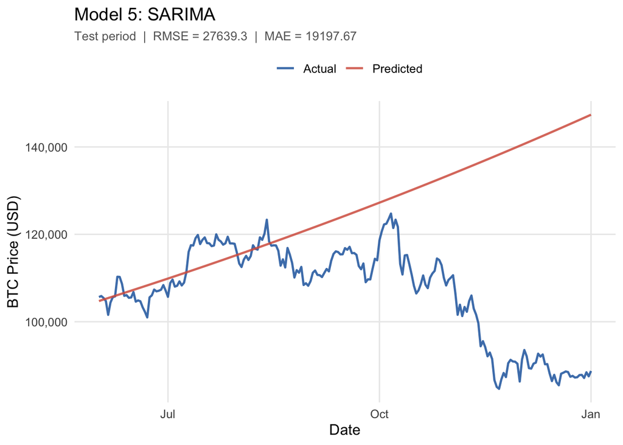

```r
plot_forecast(
  dates     = sarima_dates,
  actual    = actual_usd_sar,
  predicted = pred_usd_sar,
  title     = "Model 5: SARIMA",
  y_label   = "BTC Price (USD)",
  rmse      = rmse_usd_sar,
  mae       = mae_usd_sar
)
```

### Model 6: BSTS (USD)

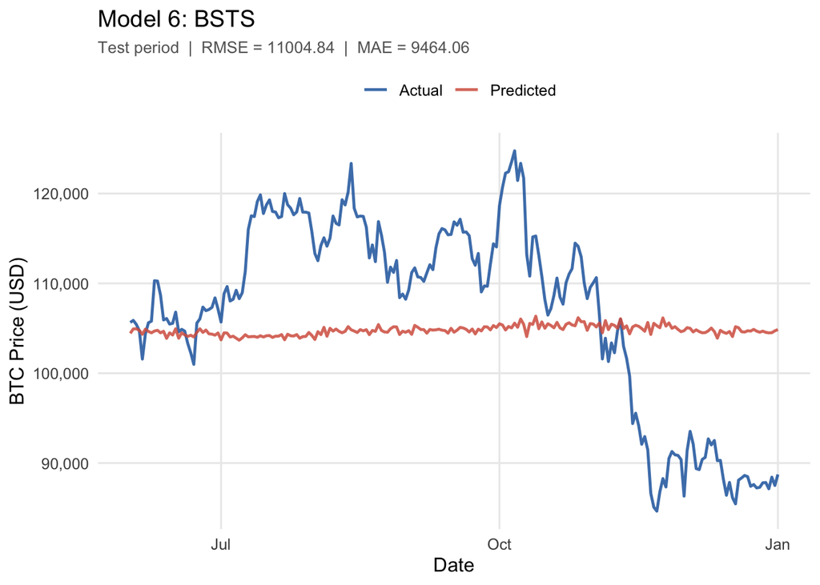

```r
plot_forecast(
  dates     = bsts_dates,
  actual    = actual_usd_bsts,
  predicted = pred_usd_bsts,
  title     = "Model 6: BSTS",
  y_label   = "BTC Price (USD)",
  rmse      = rmse_usd_bsts,
  mae       = mae_usd_bsts
)
```

## Side-by-Side Panel: All Models (USD)

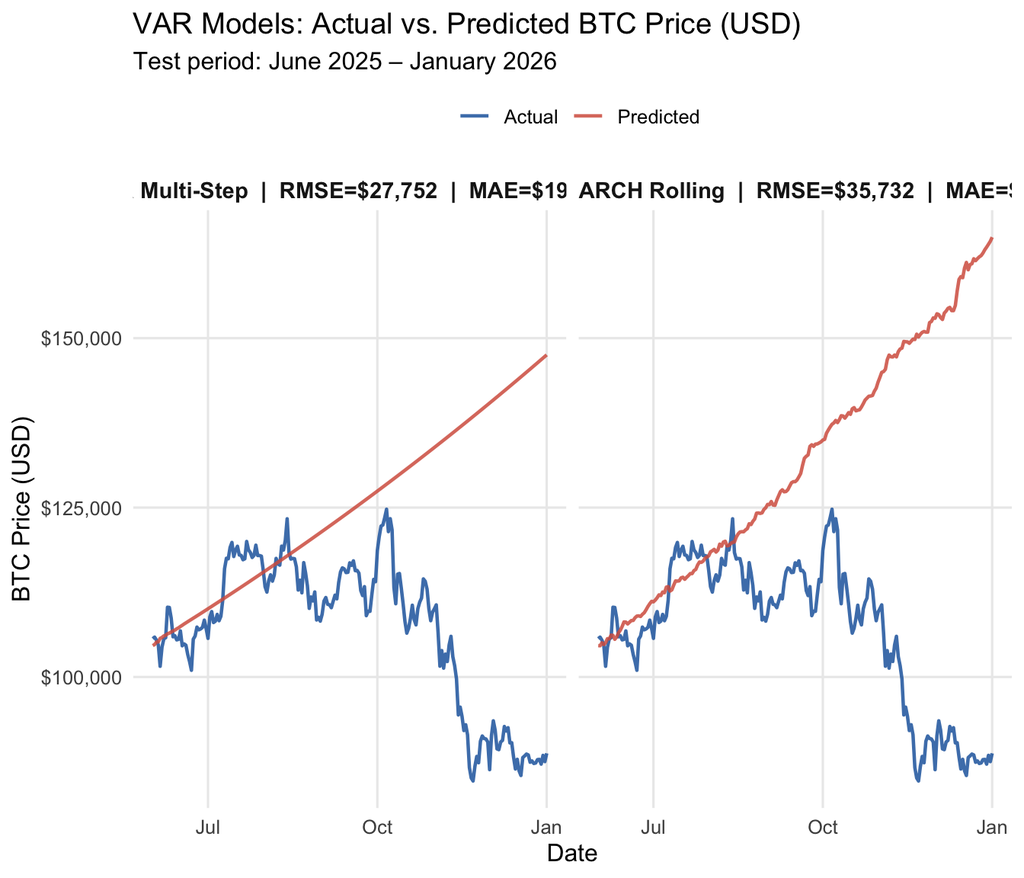

```r
# ── Slide 1: VAR & VAR+GARCH ─────────────────────────────────────────────────
panel_var <- bind_rows(
  data.frame(Date      = var_dates,
             Actual    = actual_usd_var,
             Predicted = pred_usd_var,
             Model     = sprintf("VAR Multi-Step  |  RMSE=$%s  |  MAE=$%s",
                                 format(round(rmse_usd_var), big.mark = ","),
                                 format(round(mae_usd_var),  big.mark = ","))),
  data.frame(Date      = var_dates,
             Actual    = actual_usd_vg,
             Predicted = pred_usd_vg,
             Model     = sprintf("VAR+GARCH Rolling  |  RMSE=$%s  |  MAE=$%s",
                                 format(round(rmse_usd_vg), big.mark = ","),
                                 format(round(mae_usd_vg),  big.mark = ",")))
)
panel_var$Model <- factor(panel_var$Model, levels = unique(panel_var$Model))

panel_var_long <- reshape2::melt(panel_var, id.vars = c("Date", "Model"),
                                 variable.name = "Series", value.name = "USD")

ggplot(panel_var_long, aes(x = Date, y = USD, colour = Series)) +
  geom_line(linewidth = 0.8, alpha = 0.85) +
  facet_wrap(~Model, ncol = 2, scales = "fixed") +
  scale_colour_manual(values = c("Actual" = "#2166ac", "Predicted" = "#d6604d")) +
  scale_y_continuous(labels = scales::dollar) +
  theme_minimal(base_size = 12) +
  theme(legend.position  = "top",
        strip.text        = element_text(face = "bold", size = 11),
        panel.grid.minor  = element_blank()) +
  labs(title    = "VAR Models: Actual vs. Predicted BTC Price (USD)",
       subtitle = "Test period: June 2025 – January 2026",
       x = "Date", y = "BTC Price (USD)", colour = "")
```

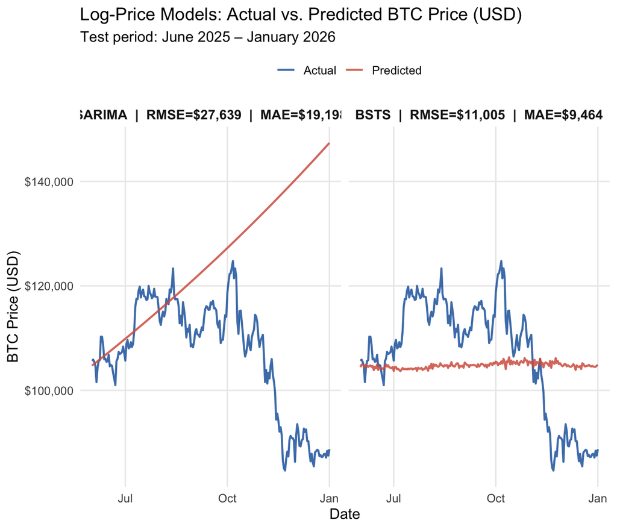

```r
# ── Slide 2: SARIMA & BSTS ───────────────────────────────────────────────────
panel_lp <- bind_rows(
  data.frame(Date      = sarima_dates,
             Actual    = actual_usd_sar,
             Predicted = pred_usd_sar,
             Model     = sprintf("SARIMA  |  RMSE=$%s  |  MAE=$%s",
                                 format(round(rmse_usd_sar), big.mark = ","),
                                 format(round(mae_usd_sar),  big.mark = ","))),
  data.frame(Date      = as.Date(bsts_dates),
             Actual    = actual_usd_bsts,
             Predicted = pred_usd_bsts,
             Model     = sprintf("BSTS  |  RMSE=$%s  |  MAE=$%s",
                                 format(round(rmse_usd_bsts), big.mark = ","),
                                 format(round(mae_usd_bsts),  big.mark = ",")))
)
panel_lp$Model <- factor(panel_lp$Model, levels = unique(panel_lp$Model))

panel_lp_long <- reshape2::melt(panel_lp, id.vars = c("Date", "Model"),
                                variable.name = "Series", value.name = "USD")

ggplot(panel_lp_long, aes(x = Date, y = USD, colour = Series)) +
  geom_line(linewidth = 0.8, alpha = 0.85) +
  facet_wrap(~Model, ncol = 2, scales = "fixed") +
  scale_colour_manual(values = c("Actual" = "#2166ac", "Predicted" = "#d6604d")) +
  scale_y_continuous(labels = scales::dollar) +
  theme_minimal(base_size = 12) +
  theme(legend.position  = "top",
        strip.text        = element_text(face = "bold", size = 11),
        panel.grid.minor  = element_blank()) +
  labs(title    = "Log-Price Models: Actual vs. Predicted BTC Price (USD)",
       subtitle = "Test period: June 2025 – January 2026",
       x = "Date", y = "BTC Price (USD)", colour = "")
```